# Prosper Loan Dataset Exploartion

## by Alaa' Nairat

## Investigation Overview

In this investigation, I aimed to explore the features of the Prosper Loan Dataset that might influence loan status. The primary focus was on the following attributes:

- `LoanOriginalAmount`
- `ListingCategory (numeric)`
- `ProsperRating (Alpha)`
- `ListingCreationDate`
- `BorrowerRate`
- `IsBorrowerHomeowner`
- `Occupation`
- `StatedMonthlyIncome`
- `EmploymentStatus`
- `DelinquenciesLast7Years`

## Dataset Overview and Executive Summary

The initial data exploration uncovered significant patterns, such as the dominance of "Current" and "Completed" loan statuses, which constitute the majority of the data. Additionally, a noticeable increase in loan amounts from 2009 to 2015 was observed.

However, inconsistencies, particularly in employment status and ProsperRating categories, as well as axis label mismatches in visualizations, require further investigation.

## What is the most frequent Loan status in the dataset?

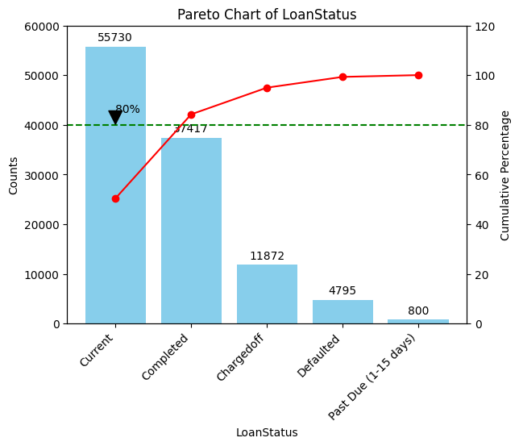

## What is the most frequent ProsperRating (Alpha) in the dataset?

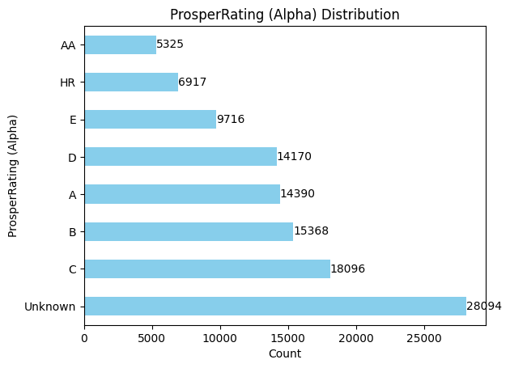

Based on the provided bar chart, "Unknown" is the most frequent ProsperRating (Alpha) in the dataset, with a count of approximately 28,094 occurrences. This is significantly higher than any other ProsperRating category.

## What is the distribution of Loan Original Amount values in the dataset?

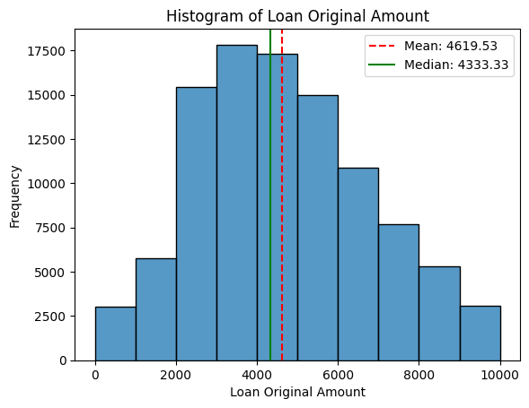

## How has the average loan amount changed over the years, and are there any noticeable trends or fluctuations in the average loan amount over time?

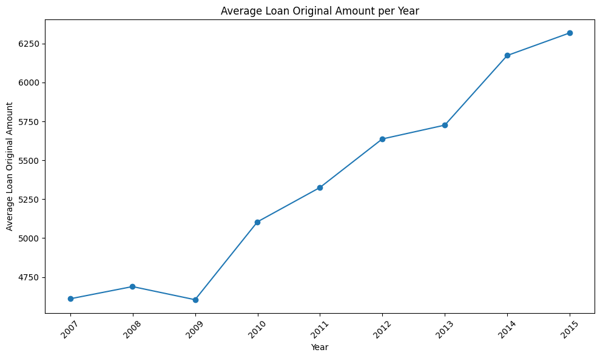

The line plot chart illustrates a significant increase in the average loan amount, starting from a value in 2009 and climbing steadily to reach 6,250 by 2015.

## How does the borrower rate vary across different loan statuses?

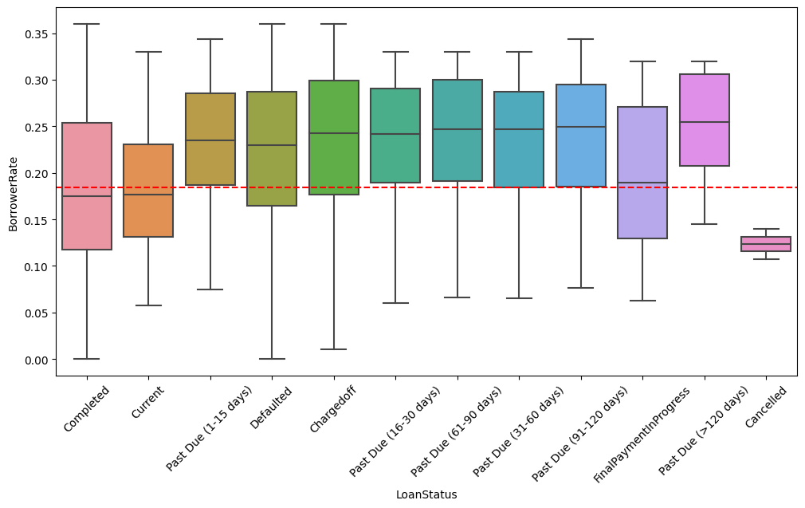

Based on the boxplot, the borrower rate appears to be highest for borrowers who have Past Due over 120 days and around the same median range for Past Due category regarding the days for. While the category Cancelled has the lowes median compared all theLoan status categories, meaning that it has the lowest borrower rate and smallest range meaning that all the values are close to each other. However, there is also a significant amount of overlap between the different loan statuses, suggesting that there is a fair amount of variation in borrower rates within each group. for example, Completed and Defaulted have the largest range and hence variation within the same group.

[output not shown]

### Submission

If you are using classroom workspace, you can choose from the following two ways of submission:

1. **Submit from the workspace**. Make sure you have removed the example project from the /home/workspace directory. You must submit the following files:
   - Part_I_notebook.ipynb
   - Part_I_notebook.html or pdf
   - Part_II_notebook.ipynb
   - Part_II_notebook.html or pdf
2. **Submit a zip file on the last page of this project lesson**. In this case, open the Jupyter terminal and run the command below to generate a ZIP file.

```
zip -r my_project.zip .
```

The command abobve will ZIP every file present in your /home/workspace directory. Next, you can download the zip to your local, and follow the instructions on the last page of this project lesson.